# Pràctica #3: Eines per resumir conjunts de dades

arnau.tibau@uab.cat

28/10/2020

**Si-us-plau, respongueu a les preguntes de manera concisa. Si no teniu clara una resposta, és millor deixar-la en blanc que explaiar-se en una explicació poc entenedora!**

L’objectiu d’aquesta pràctica no és tant el d’aprofundir en les eines d’inferència estadística que hem vist durant el Tema 2, sino familiaritzar-nos amb eines per descriure un conjunt de dades més enllà de la mitja, la variança i els estadístics d’ordre que hem vist fins ara.

En particular, treballarem amb eines típiques de l’estadística descriptiva i l’anàlisis de dades com:

- els histogrames
- la distribució cumulativa empírica
- els *boxplots*
- els *scatterplots*

Aquestes eines ens permeten entendre ràpidament les característiques principals d’un conjunt de dades, abans d’endinsar-nos en tasques més complexes d’estimació o d’inferència que normalment requereixen partir d’un model probabilístic generador de les dades observades.

## Conjunt de dades

Per aquesta pràctica farem servir un conjunt de dades clàssic. De la [font del mateix](https://web.stanford.edu/~hastie/CASI/data.html):

```
These data consist of observations on 442 patients, with the response of interest being a quantitative measure of disease progression (`prog`) one year after baseline.

There are ten baseline variables---age, sex, body-mass index (`bmi`), average blood pressure (`map`), and six blood serum measurements (`tc`, `ldl`, `hdl`, `tch`, `ltg`, `glu)`.
```

Carreguem-lo en una taula i mirem els noms de les columnes i el nombre de files:

```r
diabetes_url <- "https://web.stanford.edu/~hastie/CASI_files/DATA/diabetes.csv"
diabetes <- read.table(diabetes_url, header = TRUE, sep=",")

print(paste(c("Columnes:", paste(colnames(diabetes), collapse=", ")), collapse=" "))
```

```
## [1] "Columnes: age, sex, bmi, map, tc, ldl, hdl, tch, ltg, glu, prog"
```

```r
print(c("# rows", nrow(diabetes)))
```

```
## [1] "# rows" "442"
```

Podem fer un primer resum fent servir els estadístics que hem vist fins ara al Tema 2 (mitjana, mediana, min/max, quartils) cridant la funció `summary`:

```r
summary(diabetes)
```

```
##       age             sex              bmi             map
##  Min.   :19.00   Min.   :0.0000   Min.   :18.00   Min.   : 62.00
##  1st Qu.:38.25   1st Qu.:0.0000   1st Qu.:23.20   1st Qu.: 84.00
##  Median :50.00   Median :0.0000   Median :25.70   Median : 93.00
##  Mean   :48.52   Mean   :0.4683   Mean   :26.38   Mean   : 94.65
##  3rd Qu.:59.00   3rd Qu.:1.0000   3rd Qu.:29.27   3rd Qu.:105.00
##  Max.   :79.00   Max.   :1.0000   Max.   :42.20   Max.   :133.00
##        tc             ldl              hdl             tch
##  Min.   : 97.0   Min.   : 41.60   Min.   :22.00   Min.   :2.00
##  1st Qu.:164.2   1st Qu.: 96.05   1st Qu.:40.25   1st Qu.:3.00
##  Median :186.0   Median :113.00   Median :48.00   Median :4.00
##  Mean   :189.1   Mean   :115.44   Mean   :49.79   Mean   :4.07
##  3rd Qu.:209.8   3rd Qu.:134.50   3rd Qu.:57.75   3rd Qu.:5.00
##  Max.   :301.0   Max.   :242.40   Max.   :99.00   Max.   :9.09
##       ltg             glu              prog
##  Min.   :1.410   Min.   : 58.00   Min.   : 25.0
##  1st Qu.:1.860   1st Qu.: 83.25   1st Qu.: 87.0
##  Median :2.005   Median : 91.00   Median :140.5
##  Mean   :2.016   Mean   : 91.26   Mean   :152.1
##  3rd Qu.:2.170   3rd Qu.: 98.00   3rd Qu.:211.5
##  Max.   :2.650   Max.   :124.00   Max.   :346.0
```

**Pregunta 1**: Estudieu el resultat de la comanda `summary`. Veieu alguna cosa interessant? Fixeu-vos en la relació entre la mitjana i la mediana per cada variable, excepte per `sex`. Com ho interpreteu?

## Histograma

Un eina simple i a la vegada potent que tenim per resumir una mostra escalar és l’histograma. Donada una mostra $\left\{X_1, \cdots, X_N\right\}$, l’histograma amb $K-1$ divisions $\left\{b_1, \cdots, b_K\right\}$ es defineix com la funció que conta quantes observacions cauen en l’interval entre dues divisions adjacents:

$$\mbox{hist}_N(k) = \sum_{j=1}^N \mathbb{I}(b_{k-1} \leq X_j \leq b_k)$$
per $1 < k \leq K$. Si $K$ i $\left\{b_1, \cdots, b_K\right\}$ són fixats a priori (és a dir, no són escollits en funció de la mostra $\left\{X_1, \cdots, X_N\right\}$), aleshores podem caracteritzar l’histograma en funció de la f.d.c. de la mostra $X_i \sim F_X$:

$$\mbox{hist}_N \sim \mbox{Multinomial}(p_1, \cdots, p_K, N)$$
on $p_i = F_X(b_i) - F_X(b_{i-1})$.

Per altra banda, tindrem que:

$$E(\mbox{hist}_N(i)) = \sum_{j=1}^N E(\mathbb{I}(b_{i-1} \leq X_j \leq b_i))=N p_i$$
i

$$\mbox{Var}(\mbox{hist}_N(k)) = \frac{p_i(1-p_i)}{N}$$
Per tant, l’histograma es pot interpretar com una estimació de la f.m.p. corresponent a discretitzar la mostra en $K$ nivells (en el cas que la variable d’interès sigui contínua) o simplement com una estimació de la f.m.p. si la mostra és discreta i $K$ és igual a la cardinalitat de l’imatge de $F_X$.

En general però, **escollirem $K$ i $b_k$ en funció de les dades, per tant les expressions anteriors no seran vàlides**, ja que no tindrien en compte la dependència de $K$, $b_k$ i $X_i$. A la pràctica, es sol escollir $b_{0}=X_{(1)}$ i $b_{k} = b_{0} + k \frac{X_{(N)} - X_{(1)}}{K}$, i hi ha diversos algorismes per escollir el valor de $K$, veure la documentació de la funció `hist` en R per més informació.

**Pregunta 2**: Grafiqueu els histogrames de les columnes `bmi`, `age` i `glu`. Què podeu concloure sobre la distribució de cada una d’elles? (Podeu jugar amb el paràmetre `breaks` de la funció `hist` per obtenir diferents nivells de granularitat.)

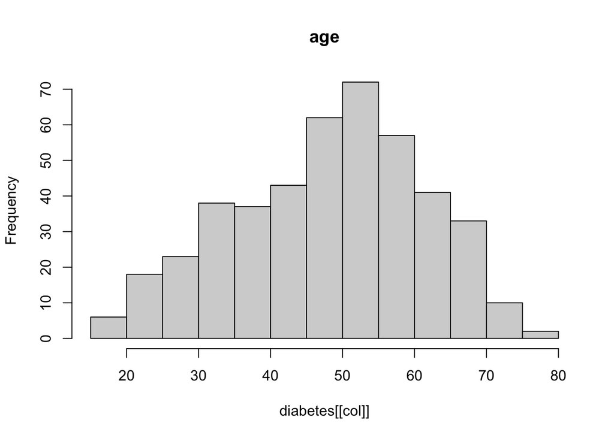

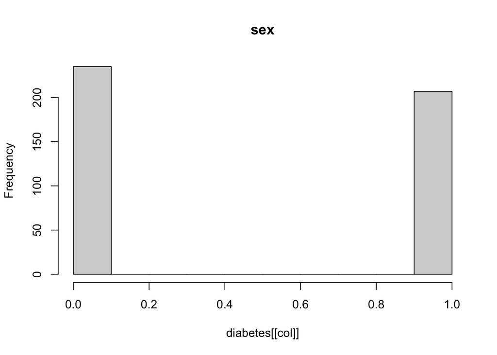

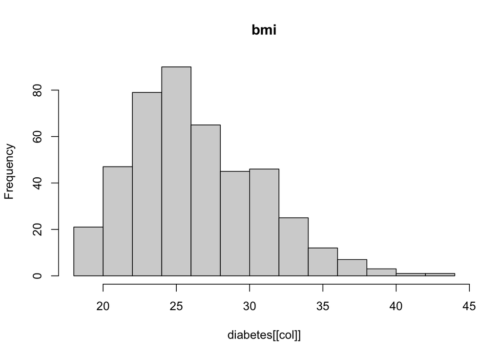

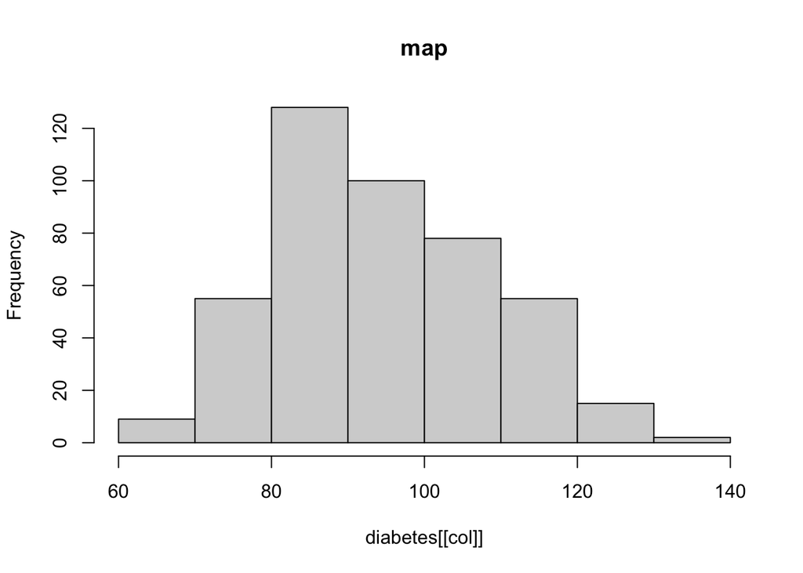

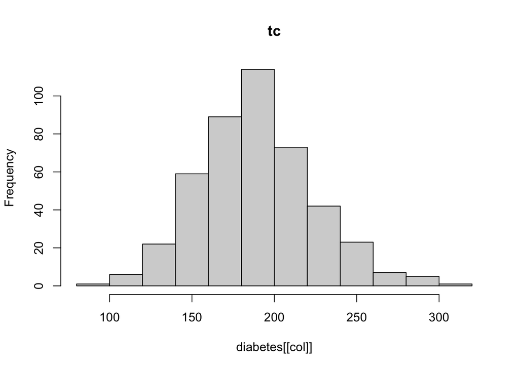

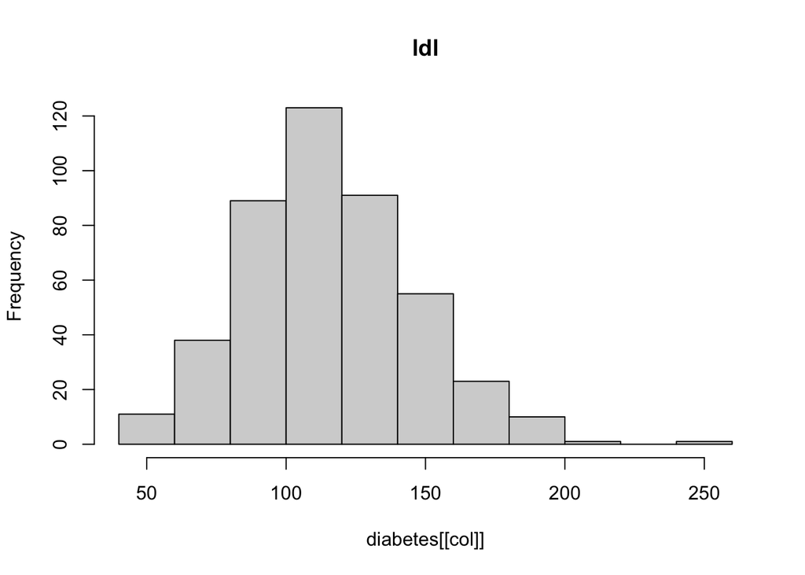

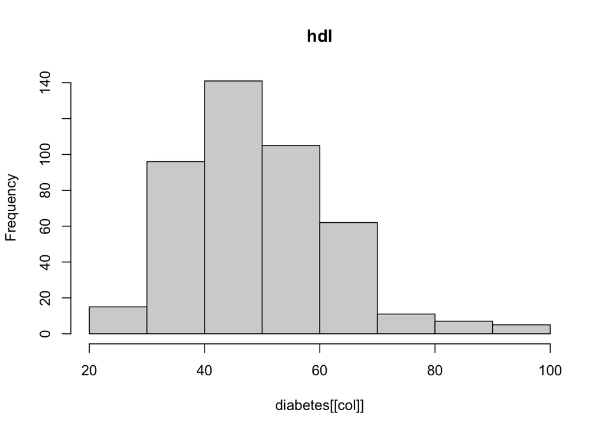

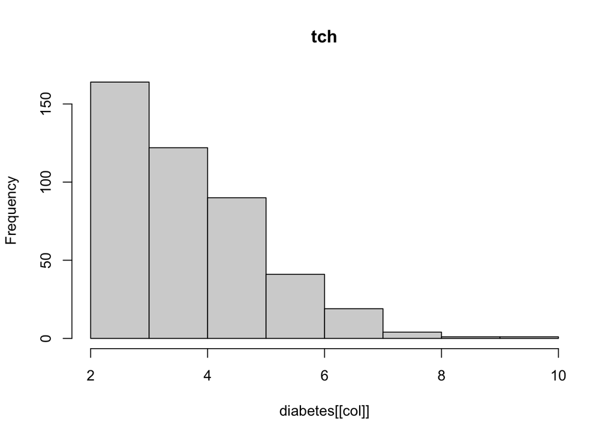

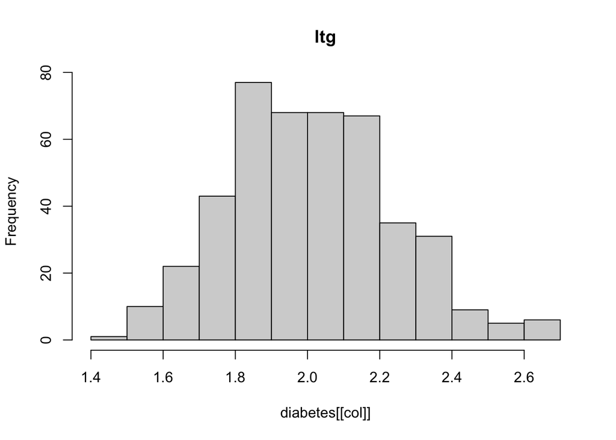

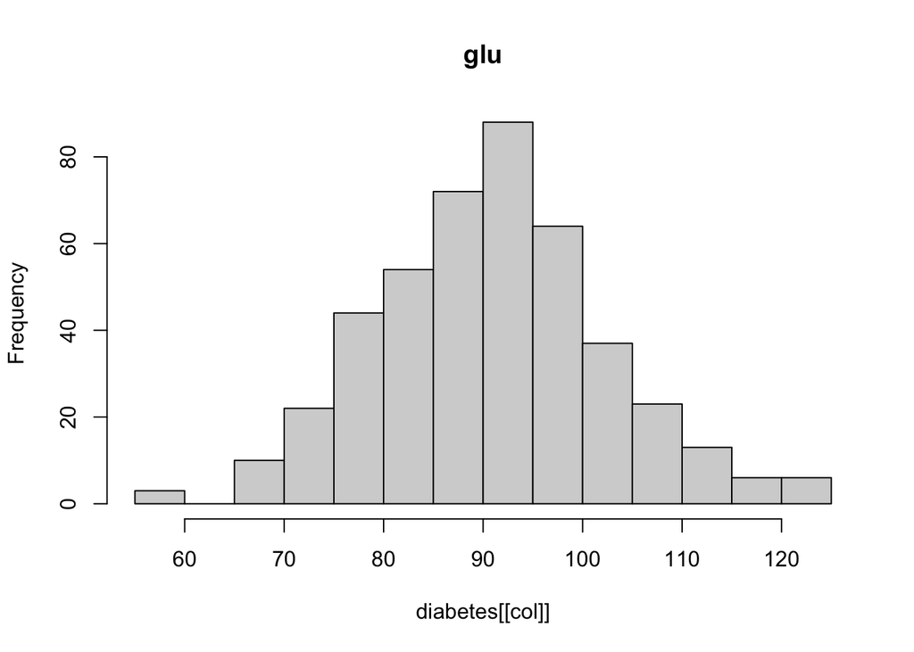

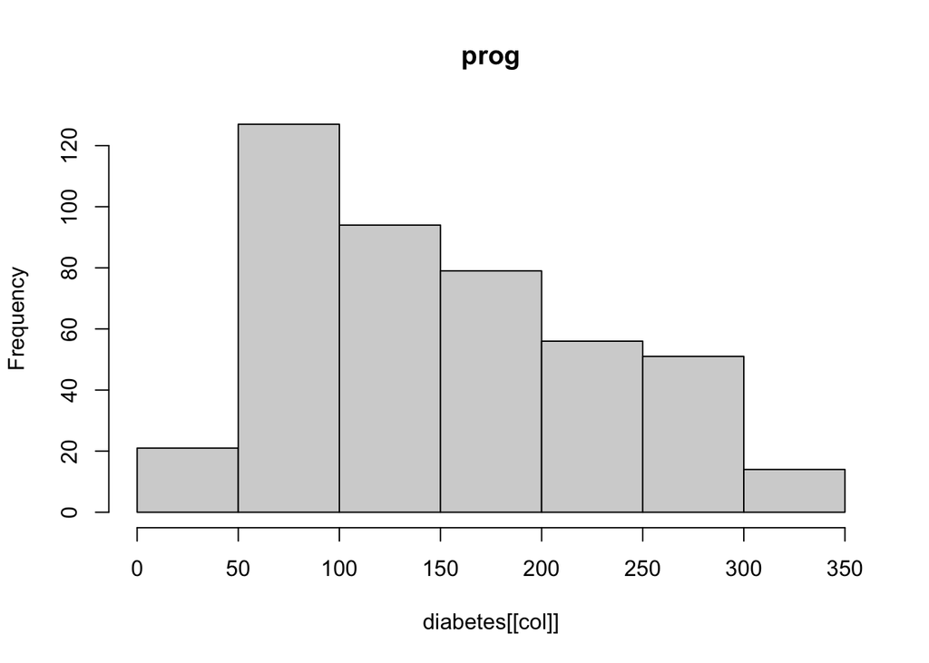

```r
for (col in colnames(diabetes)){
  hist(diabetes[[col]], main = col)
}
```

## Funció de distribució cumulativa empírica

Donada una mostra $\left\{X_1, \cdots, X_N\right\}$, la f.d.c empírica es una funció (aleatòria) definida com:

$$\hat{F}_N(x) = \frac{1}{N}\left|i: X_i \leq x\right| = \frac{1}{N}\sum_{i=1}^N \mathbb{I}(X_i \leq x)$$
on $|S|$ és la cardinalitat d’un conjunt S, i $\mathbb{I}(P)$ és la funció indicatriu, retornant 1 si el predicat $P$ es verifica i 0 altrament. Fixeu-vos que, per definició:

$$\hat{F}_N(X_{(k)}) - \hat{F}_N(X_{(k-1)}) = \frac{\left|i: X_i = X_{(k)}\right|}{N}$$
és a dir la f.d.c.e. té “salts” de tamany proporcional al nombre d’elements en la mostra que prenen un cert valor $X_{(k)}$ (podeu revisar el significat de la notació $X_{(k)}$ que vem veure a classe).

És bastant directe adonar-se que si $X_i \sim F_X$ (la f.d.c caracteritzant la mostra), per un $x$ donat:

$$N \times \hat{F}_N(x) \sim \mbox{Binomial}(F_X(x), N)$$
i per tant, per propietats de la binomial, $\hat{F}_N(x)$ és un estimador sense biaix de $F_X(x)$:

$$E(\hat{F}_N(x)) = F_X(x)$$
i té variança:

$$\mbox{Var}(\hat{F}_N(x)) = \frac{F_X(x)(1- F_X(x))}{N}$$
(és important entendre que aquests resultats els obtenim *per cada* $x$ **per separat**!). Per la llei dels grans nombres, aquests dos resultats impliquen que $\hat{F}_N(x) \to F_X(x)$, per cada $x$ (és a dir, no necessàriament per *tots* els x a la vegada, això requereix un desenvolupament molt més complicat!).

**Pregunta 3**: Genereu una mostra de talla $N=1000$ de $X \sim \mbox{Uniforme}[0,1]$. Grafiqueu $F_X$ i $\hat{F}_N(x)$ (podeu feu servir la funció `ecdf` en R per calcular $\hat{F}_N(x)$).

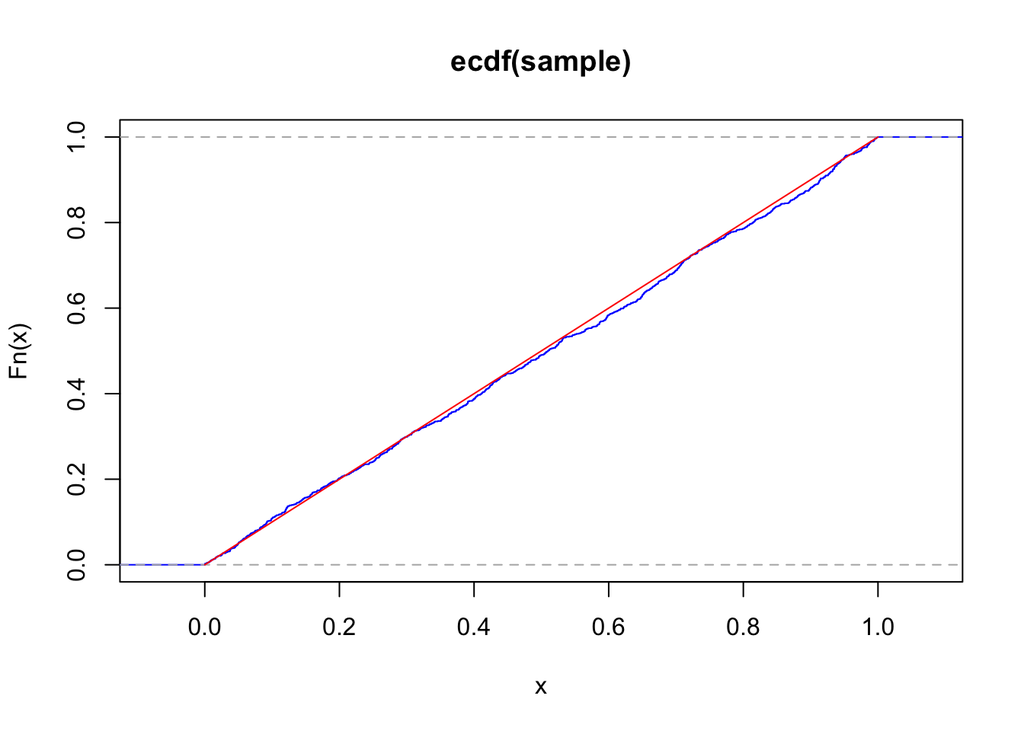

```r
sample = runif(1000)
plot(ecdf(sample), col='blue')
x = seq(0, 1, 0.01)
lines(x, x, col='red')
```

Per tant, si tracem la recta que passa per $(X_{(1)},0)$ i $(X_{(N)}, 1)$ i la comparem amb $\hat{F}_N(x)$ ens dona una idea de com s’assembla la mostra a la que veuriem si $X$ estigués distribuïda uniformement:

**Pregunta 4**: Grafiqueu $\hat{F}_N(x)$ per `diabetes$bmi` i compareu-la amb la f.d.c.e d’una distribució uniforme entre `min(diabetes$bmi)` i `max(diabetes$bmi)`. Creieu que és versemblant que `diabetes$bmi` sigui uniforme? Quina diferència hi veieu?

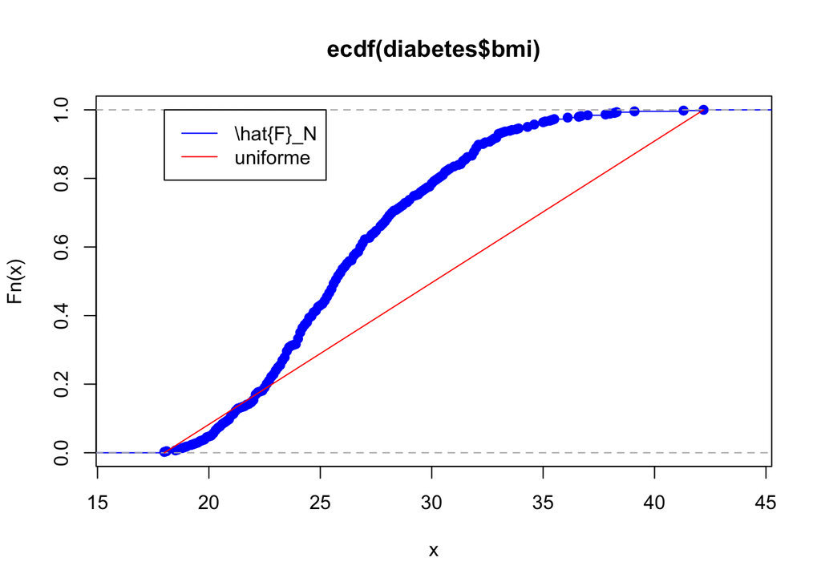

```r
plot(ecdf(diabetes$bmi), col='blue')
lines(c(min(diabetes$bmi), max(diabetes$bmi)), c(0, 1), col='red')
legend(min(diabetes$bmi), 1, c("\\hat{F}_N", 'uniforme'), col = c('blue', 'red'), lty = 1)
```

La f.d.c.e. també es pot fer servir per veure ràpidament relacions entre la variable d’interès i subgrups de la mostra com veurem a continuació:

**Pregunta 5**: Grafiqueu la f.d.c.e. de l’edat (`age`) pel subconjunt de mostres tals que `prog < 140` i pel subconjunt de mostres tals que `prog >= 140` (en una mateixa gràfica). Què observeu? Com ho interpreteu?

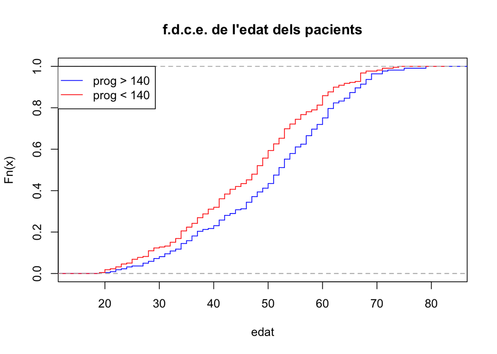

```r
plot(ecdf(subset(diabetes$age, diabetes$prog > 140)),
     col='blue', main="f.d.c.e. de l'edat dels pacients", lty=1, do.points=FALSE, verticals=TRUE, xlab='edat')
lines(ecdf(subset(diabetes$age, diabetes$prog < 140)), col='red', lty=1, do.points=FALSE, verticals=TRUE)
legend(10, 1, c("prog > 140", "prog < 140"), col = c('blue', 'red'), lty = 1)
```

## Boxplots

Els histogrames i les f.d.c.e. són útils però sovint ens interessa visualitzar la distribució del nostre conjunt de dades d’una manera més compacta, per exemple per tal de comparar les distribucions entre columnes.

Els [boxplots](https://en.wikipedia.org/wiki/Box_plot) són un mètode per visualitzar els trets més importants d’una distribució de manera concisa:

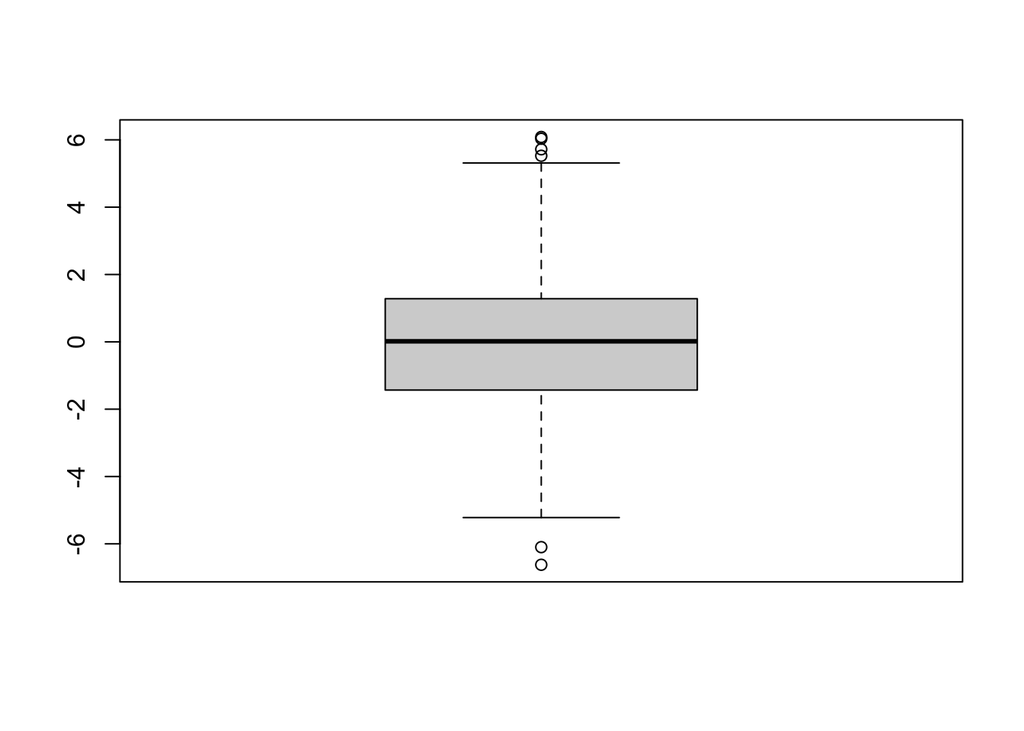

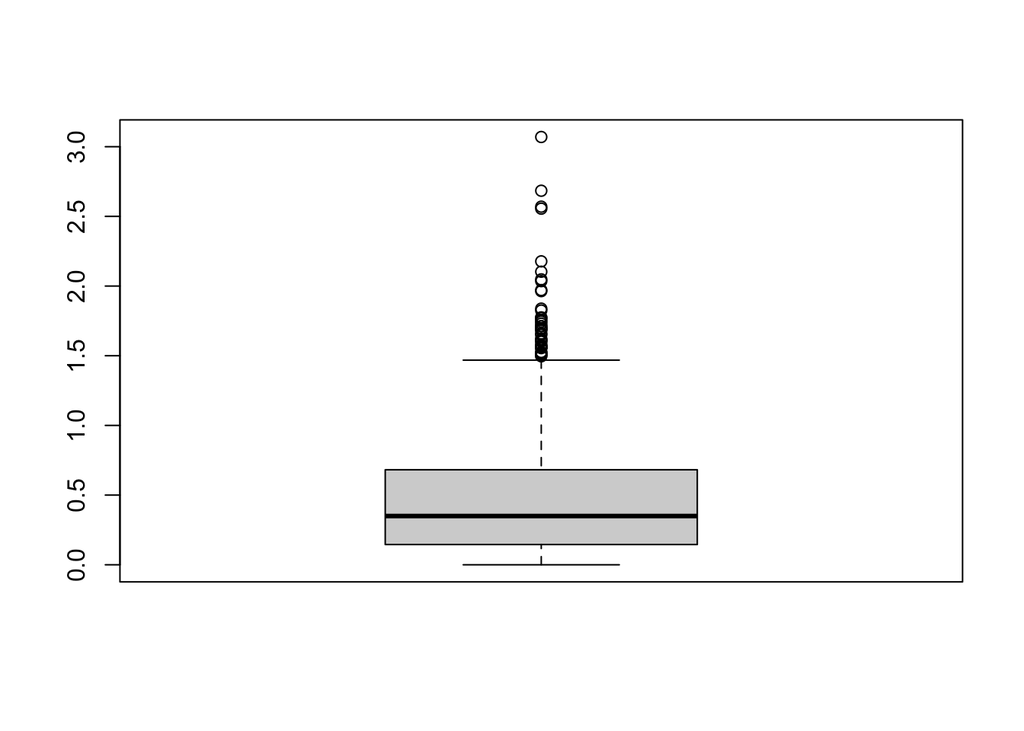

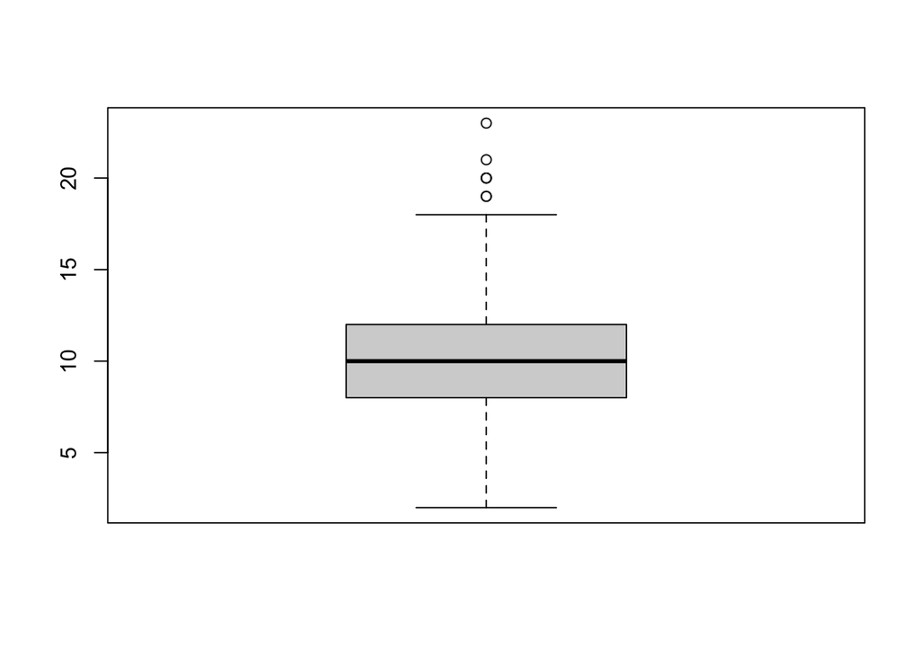

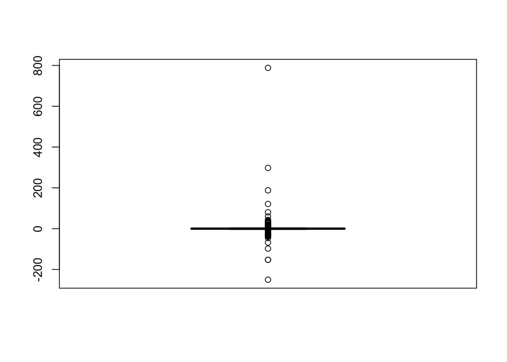

```r
df = data.frame(norm=rnorm(1000, 0, 2))
df$exp = rexp(1000, 2)
df$poisson = rpois(1000, 10)
df$cauchy = rcauchy(1000, 0, 1)

for (col in colnames(df)){
  boxplot(df[[col]])
}
```

Els boxplots són expecialment útils per trobar associacions entre dades contínues i dades discretes o categòriques:

**Pregunta 7**: Feu servir la funció `boxplot` per graficar el boxplot de `bmi` en funció del `sex`: `boxplot(bmi ~ sex, diabetes)`. Què hi veieu? I si grafiquem `boxplot(map ~ sex, diabetes)`?

## Scatterplots

Acabem de veure com els *boxplots* ens poden servir per trobar associacions entre variables categòriques (ex: `sex`) i variables contínues (ex: `map`). Un altra eina molt útil per buscar aquestes associacions entre parells de columnes són els *scatterplots*.

Els *scatterplots* són molt senzills, només grafiquen una sèrie de parells $(X_i, Y_i)$ sobre uns eixos (x, y) en el pla. Veiem-ne un exemple:

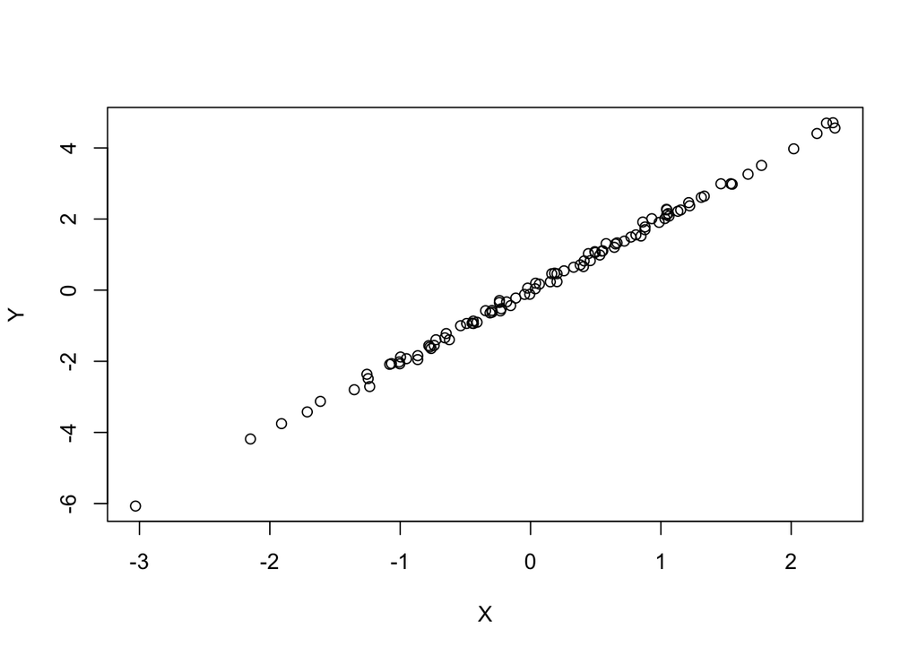

```r
X = rnorm(100, 0, 1)
Y = 2*X + rnorm(100, 0, 0.1)

plot(X, Y)
```

Com que la mostra d’X i la d’Y estàn altament associades (hem generat Y a partir d’una petita perturbació d’X), l’*scatterplot* de X vs. Y ens mostra aquesta clara associació linear. Podriem generar altres tipus d’associacions (per exemple $Y = X^2 + \epsilon$) i l’scatterplot ambé ens donaria una vista ràpida de la seva forma.

**Pregunta 8**: Grafiqueu l’*scatterplot* de les columnes `diabetes$tc` vs. `diabetes$ldl`. Feu-ho de nou amb les columnes `diabtes$hdl` vs. `diabetes$tch`. Calculeu el coeficient de correlació (`cor`) per ambdos casos. Quines conclusions en treieu?

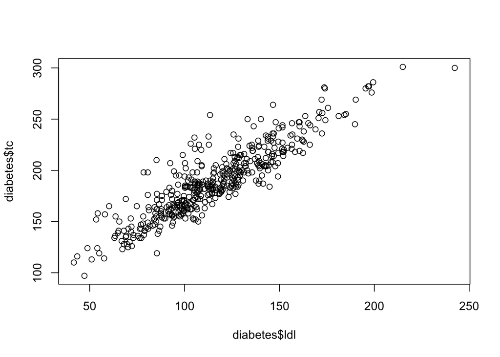

```r
plot(diabetes$ldl, diabetes$tc)
```

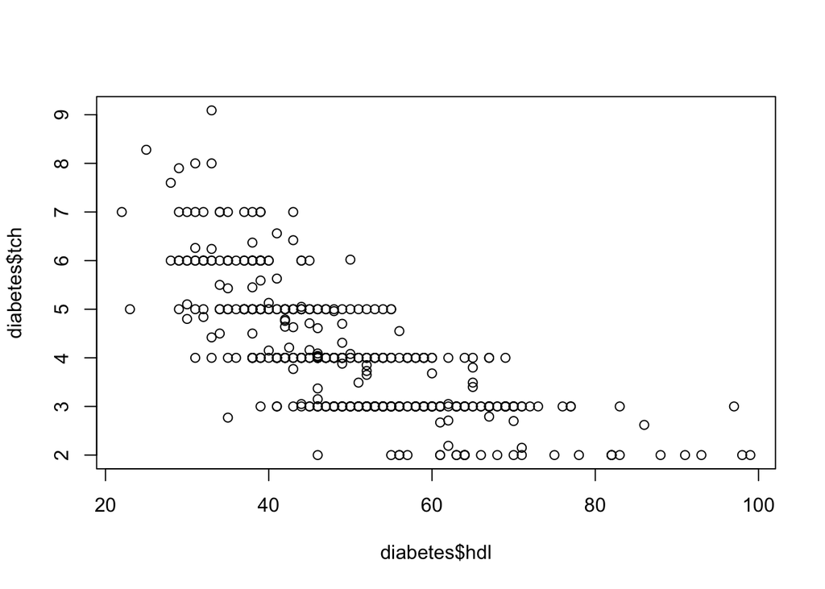

```r
plot(diabetes$hdl, diabetes$tch)
```